# **Male aDN>TNT courtship behaviour in the light**

Aaron M. Allen

5th December 2020

# **Load packages**

Loading in the packages that we'll need for the analysis.

```r
library(tidyverse)
library(survminer)
library(survival)
library(data.table)
library(ggpubr)
library(zoo)
library(ggbeeswarm)
library(cowplot)
```

# **Load data**

This first bit is a lot of data import and manipulation to get it already to plot the courtship features.

First we'll load in the "key" tables with the genotypes, and do a little cleaning.

```r
genotypes <- read_tsv("../2019_03_06_Courtship/genotype.tsv",col_names = TRUE)
head(genotypes)
```

| video | fly_id | genotype | copulation_time |
| --- | --- | --- | --- |
| Megan-2019_03_06_Courtship-DsxVglutTNT_Male_1234_2 | 3 | A | 480 |
| Megan-2019_03_06_Courtship-DsxVglutTNT_Male_1234_2 | 5 | A | 480 |
| Megan-2019_03_06_Courtship-DsxVglutTNT_Male_1234_2 | 7 | A | 667 |
| Megan-2019_03_06_Courtship-DsxVglutTNT_Male_1234_2 | 13 | A | 751 |
| Megan-2019_03_06_Courtship-DsxVglutTNT_Male_1234_2 | 15 | A | 244 |
| Megan-2019_03_06_Courtship-DsxVglutTNT_Male_1234_2 | 17 | A | 440 |

We also want to populate this table with the Id numbers for the matched females in each chamber. We are simply duplicating the `genotypes` table and if the male `fly_id` was odd, then we increment the female Id, and if the male `fly_id` was even then we decrement the Id. Finally we change the genotype to "*CS*".

```r
female_genotypes <- genotypes
even_ids <- (genotypes$fly_id %% 2) == 0
odd_ids <- (genotypes$fly_id %% 2) != 0
female_genotypes$fly_id[even_ids] = female_genotypes$fly_id[even_ids] - 1
female_genotypes$fly_id[odd_ids] = female_genotypes$fly_id[odd_ids] + 1
female_genotypes$genotype <- "CS"
head(female_genotypes)
```

| video | fly_id | genotype | copulation_time |
| --- | --- | --- | --- |
| Megan-2019_03_06_Courtship-DsxVglutTNT_Male_1234_2 | 4 | CS | 480 |
| Megan-2019_03_06_Courtship-DsxVglutTNT_Male_1234_2 | 6 | CS | 480 |
| Megan-2019_03_06_Courtship-DsxVglutTNT_Male_1234_2 | 8 | CS | 667 |
| Megan-2019_03_06_Courtship-DsxVglutTNT_Male_1234_2 | 14 | CS | 751 |
| Megan-2019_03_06_Courtship-DsxVglutTNT_Male_1234_2 | 16 | CS | 244 |
| Megan-2019_03_06_Courtship-DsxVglutTNT_Male_1234_2 | 18 | CS | 440 |

Now we merge the male and female `genotypes` tables.

```r
all_genotypes <- bind_rows(genotypes,female_genotypes)
all_genotypes <- all_genotypes %>%
  unite("uni_fly",video,fly_id,remove = FALSE)
head(all_genotypes)
```

| uni_fly | video | fly_id | genotype | copulation_time |
| --- | --- | --- | --- | --- |
| Megan-2019_03_06_Courtship-DsxVglutTNT_Male_1234_2_3 | Megan-2019_03_06_Courtship-DsxVglutTNT_Male_1234_2 | 3 | A | 480 |
| Megan-2019_03_06_Courtship-DsxVglutTNT_Male_1234_2_5 | Megan-2019_03_06_Courtship-DsxVglutTNT_Male_1234_2 | 5 | A | 480 |
| Megan-2019_03_06_Courtship-DsxVglutTNT_Male_1234_2_7 | Megan-2019_03_06_Courtship-DsxVglutTNT_Male_1234_2 | 7 | A | 667 |
| Megan-2019_03_06_Courtship-DsxVglutTNT_Male_1234_2_13 | Megan-2019_03_06_Courtship-DsxVglutTNT_Male_1234_2 | 13 | A | 751 |
| Megan-2019_03_06_Courtship-DsxVglutTNT_Male_1234_2_15 | Megan-2019_03_06_Courtship-DsxVglutTNT_Male_1234_2 | 15 | A | 244 |
| Megan-2019_03_06_Courtship-DsxVglutTNT_Male_1234_2_17 | Megan-2019_03_06_Courtship-DsxVglutTNT_Male_1234_2 | 17 | A | 440 |

And now we can read in all the csv files with all the raw tracking and JAABA annotated behaviours.

```r
rawdata_list <- list.files("../2019_03_06_Courtship/",recursive = TRUE) %>% str_subset("_ALLDATA.csv") %>% str_subset("_Male_")
all_rawdata <- tibble()
for (rawdata_file in rawdata_list) {
  temp <- fread(input = paste0("../2019_03_06_Courtship/",rawdata_file), showProgress = FALSE)
  all_rawdata <- bind_rows(all_rawdata,temp)
}
head(all_rawdata)
```

| FileName | StartPosition | Arena | Id | Frame | Approaching | Contact | Copulation | Encircling | Facing | Turning | WingGesture | vel__mmpers | ang_vel__radpers | min_wing_ang__rad | max_wing_ang__rad | mean_wing_length__mm | axis_ratio__ratio | fg_body_ratio__ratio | contrast__ | dist_to_wall__mm | dist_to_other__mm | angle_between__rad | facing_angle__rad | leg_dist__mm | pos_x__px | pos_y__px | ori__rad | major_axis_len__px | minor_axis_len__px | … |
| --- | --- | --- | --- | --- | --- | --- | --- | --- | --- | --- | --- | --- | --- | --- | --- | --- | --- | --- | --- | --- | --- | --- | --- | --- | --- | --- | --- | --- | --- | --- |
| Megan-2019_03_06_Courtship-DsxVglutTNT_Male_123_3 | r | 1 | 1 | 1 | 0 | 0 | 0 | 0 | 0 | 0 | 0 | 10.568136 | 7.179909 | 0.04786277 | 0.10871320 | 1.703547 | 2.935180 | 2.554348 | 0.5618692 | 1.136478 | 14.00891 | 1.378507 | 2.838113 | 10.442659 | 590.1775 | 221.8043 | -1.049234 | 32.59140 | 11.10371 | … |
| Megan-2019_03_06_Courtship-DsxVglutTNT_Male_123_3 | r | 1 | 1 | 2 | 0 | 0 | 0 | 0 | 0 | 0 | 0 | 10.568136 | 7.749848 | 0.05421675 | 0.14069897 | 1.691783 | 2.924973 | 2.557042 | 0.6361945 | 1.430171 | 13.66152 | 1.658525 | 2.578570 | 10.392858 | 583.7313 | 225.1231 | -1.336430 | 32.13478 | 11.09920 | … |
| Megan-2019_03_06_Courtship-DsxVglutTNT_Male_123_3 | r | 1 | 1 | 3 | 0 | 0 | 0 | 0 | 0 | 0 | 0 | 8.197352 | 7.093708 | 0.06586711 | 0.10872405 | 1.656073 | 2.976259 | 2.606252 | 0.6430395 | 1.662054 | 13.22971 | 1.857585 | 2.347330 | 10.085876 | 581.6058 | 227.8686 | -1.714817 | 32.60260 | 10.96163 | … |
| Megan-2019_03_06_Courtship-DsxVglutTNT_Male_123_3 | r | 1 | 1 | 4 | 0 | 0 | 0 | 0 | 0 | 0 | 0 | 8.195031 | 4.019496 | 0.06568391 | 0.07072531 | 1.665366 | 3.001512 | 2.670758 | 0.6501939 | 1.903141 | 12.72482 | 1.863409 | 2.288914 | 9.611159 | 576.1273 | 229.6704 | -1.805841 | 32.86135 | 10.73441 | … |
| Megan-2019_03_06_Courtship-DsxVglutTNT_Male_123_3 | r | 1 | 1 | 5 | 0 | 0 | 0 | 0 | 0 | 0 | 0 | 9.561028 | 2.143555 | 0.05662871 | 0.07672840 | 1.678793 | 2.993530 | 2.682923 | 0.6616260 | 2.002010 | 12.30533 | 1.821112 | 2.354494 | 9.375500 | 574.1978 | 235.5149 | -1.723156 | 32.07957 | 11.02701 | … |
| Megan-2019_03_06_Courtship-DsxVglutTNT_Male_123_3 | r | 1 | 1 | 6 | 0 | 0 | 0 | 0 | 0 | 0 | 0 | 10.188806 | 1.906437 | 0.05674809 | 0.09789343 | 1.682552 | 3.012756 | 2.715606 | 0.6578252 | 2.092929 | 12.05360 | 1.849265 | 2.420021 | 9.106038 | 569.9073 | 240.0077 | -1.809730 | 32.43910 | 10.48301 | … |

Define a few functions to compute the relative x and y postions of each fly in each chamber.

```r
# calculates relative y value based on data from feat.mat
calculate_yrel <- function(theta,dist){
  yrel=dist*cos(theta)
  return(yrel)
}
calculate_xrel <- function(ori,xmale,xfemale,yrel,ppm=14.85){
  xmale_mm=xmale/ppm
  xfemale_mm=xfemale/ppm
  xrel = (xfemale_mm - (cos(ori)*yrel+xmale_mm))/(sin(ori))
  return(xrel)
}
calculate_xrel_abs <- function(theta,dist){
  xrel=dist*sin(theta)
  return(xrel)
}
```

And calculate those relative x and y positions.

```r
all_rawdata <- all_rawdata %>%
  arrange(FileName,Arena,Frame)

all_rawdata$rel_y_other <- NA
all_rawdata$rel_x_other <- NA
all_rawdata$rel_x_abs_other <- NA
all_rawdata$rel_x_abs_corr_other <- NA

all_rawdata$rel_y_other[seq(1,nrow(all_rawdata),2)] = calculate_yrel(all_rawdata$facing_angle__rad[seq(1,nrow(all_rawdata),2)],
                                                         all_rawdata$dist_to_other__mm[seq(1,nrow(all_rawdata),2)])

all_rawdata$rel_x_other[seq(1,nrow(all_rawdata),2)] = calculate_xrel(ori = all_rawdata$ori__rad[seq(1,nrow(all_rawdata),2)],
                                                         xmale = all_rawdata$pos_x__px[seq(1,nrow(all_rawdata),2)],
                                                         xfemale = all_rawdata$pos_x__px[seq(2,nrow(all_rawdata),2)],
                                                         yrel = calculate_yrel(all_rawdata$facing_angle__rad[seq(1,nrow(all_rawdata),2)],
                                                                               all_rawdata$dist_to_other__mm[seq(1,nrow(all_rawdata),2)]))

all_rawdata$rel_x_abs_other[seq(1,nrow(all_rawdata),2)] = calculate_xrel_abs(all_rawdata$facing_angle__rad[seq(1,nrow(all_rawdata),2)],
                                                                 all_rawdata$dist_to_other__mm[seq(1,nrow(all_rawdata),2)])


all_rawdata$rel_y_other[seq(2,nrow(all_rawdata),2)] = calculate_yrel(all_rawdata$facing_angle__rad[seq(2,nrow(all_rawdata),2)],
                                                         all_rawdata$dist_to_other__mm[seq(2,nrow(all_rawdata),2)])

all_rawdata$rel_x_other[seq(2,nrow(all_rawdata),2)] = calculate_xrel(ori = all_rawdata$ori__rad[seq(2,nrow(all_rawdata),2)],
                                                         xmale = all_rawdata$pos_x__px[seq(2,nrow(all_rawdata),2)],
                                                         xfemale = all_rawdata$pos_x__px[seq(1,nrow(all_rawdata),2)],
                                                         yrel = calculate_yrel(all_rawdata$facing_angle__rad[seq(2,nrow(all_rawdata),2)],
                                                                               all_rawdata$dist_to_other__mm[seq(2,nrow(all_rawdata),2)]))

all_rawdata$rel_x_abs_other[seq(2,nrow(all_rawdata),2)] = calculate_xrel_abs(all_rawdata$facing_angle__rad[seq(2,nrow(all_rawdata),2)],
                                                                 all_rawdata$dist_to_other__mm[seq(2,nrow(all_rawdata),2)])


all_rawdata$rel_x_abs_corr_other[which(all_rawdata$rel_x_other<0)] = -all_rawdata$rel_x_abs_other[which(all_rawdata$rel_x_other<0)]
all_rawdata$rel_x_abs_corr_other[which(all_rawdata$rel_x_other>0)] = all_rawdata$rel_x_abs_other[which(all_rawdata$rel_x_other>0)]

head(all_rawdata)
```

| FileName | StartPosition | Arena | Id | Frame | Approaching | Contact | Copulation | Encircling | Facing | Turning | WingGesture | vel__mmpers | ang_vel__radpers | min_wing_ang__rad | max_wing_ang__rad | mean_wing_length__mm | axis_ratio__ratio | fg_body_ratio__ratio | contrast__ | dist_to_wall__mm | dist_to_other__mm | angle_between__rad | facing_angle__rad | leg_dist__mm | pos_x__px | pos_y__px | ori__rad | major_axis_len__px | minor_axis_len__px | … |
| --- | --- | --- | --- | --- | --- | --- | --- | --- | --- | --- | --- | --- | --- | --- | --- | --- | --- | --- | --- | --- | --- | --- | --- | --- | --- | --- | --- | --- | --- | --- |
| Megan-2019_03_06_Courtship-DsxVglutTNT_Male_123_3 | r | 1 | 1 | 1 | 0 | 0 | 0 | 0 | 0 | 0 | 0 | 10.568136 | 7.1799089 | 0.04786277 | 0.10871320 | 1.703547 | 2.935180 | 2.554348 | 0.5618692 | 1.136478 | 14.00891 | 1.378507 | 2.838113 | 10.44266 | 590.1775 | 221.80435 | -1.0492340 | 32.59140 | 11.10371 | … |
| Megan-2019_03_06_Courtship-DsxVglutTNT_Male_123_3 | l | 1 | 2 | 1 | 0 | 0 | 0 | 0 | 0 | 0 | 0 | 9.313276 | 0.3296027 | 0.03169229 | 0.03361545 | 1.964383 | 2.885028 | 2.156398 | 0.3333929 | 2.007741 | 14.00891 | 1.378507 | 1.075027 | 10.44266 | 438.3910 | 81.59953 | 0.3292730 | 40.12086 | 13.90658 | … |
| Megan-2019_03_06_Courtship-DsxVglutTNT_Male_123_3 | r | 1 | 1 | 2 | 0 | 0 | 0 | 0 | 0 | 0 | 0 | 10.568136 | 7.7498476 | 0.05421675 | 0.14069897 | 1.691783 | 2.924973 | 2.557042 | 0.6361945 | 1.430171 | 13.66152 | 1.658525 | 2.578570 | 10.39286 | 583.7313 | 225.12313 | -1.3364304 | 32.13478 | 11.09920 | … |
| Megan-2019_03_06_Courtship-DsxVglutTNT_Male_123_3 | l | 1 | 2 | 2 | 0 | 0 | 0 | 0 | 0 | 0 | 0 | 9.313276 | 0.7494085 | 0.03267351 | 0.03867090 | 1.963994 | 2.891028 | 2.168572 | 0.3421920 | 2.007741 | 13.66152 | 1.658525 | 1.095502 | 10.39286 | 442.9258 | 80.85167 | 0.3160889 | 40.17955 | 13.83024 | … |
| Megan-2019_03_06_Courtship-DsxVglutTNT_Male_123_3 | r | 1 | 1 | 3 | 0 | 0 | 0 | 0 | 0 | 0 | 0 | 8.197352 | 7.0937078 | 0.06586711 | 0.10872405 | 1.656073 | 2.976259 | 2.606252 | 0.6430395 | 1.662054 | 13.22971 | 1.857585 | 2.347330 | 10.08588 | 581.6058 | 227.86861 | -1.7148169 | 32.60260 | 10.96163 | … |
| Megan-2019_03_06_Courtship-DsxVglutTNT_Male_123_3 | l | 1 | 2 | 3 | 0 | 0 | 0 | 0 | 0 | 0 | 0 | 13.338888 | 2.1172004 | 0.03839770 | 0.04893779 | 1.961599 | 2.864308 | 2.139074 | 0.3606669 | 2.088532 | 13.22971 | 1.857585 | 1.063322 | 10.08588 | 451.2227 | 81.24645 | 0.2357359 | 39.98133 | 13.93711 | … |

Using the copulation frames from the `all_genotypes` table we can subset the raw tracking data to remove all copulatory frames. We are then left with the non-copulatory frames.

```r
all_rawdata <- all_rawdata %>%
  unite("uni_fly",FileName,Id,remove = FALSE)

non_cop_frames <- tibble()
flies <- unique(all_genotypes$uni_fly)
for (fly in flies) {
  cop_time <- all_genotypes$copulation_time[all_genotypes$uni_fly==fly]
  cop_time <- replace_na(cop_time,900)
  cop_time <- cop_time*25
  temp0 <- all_rawdata %>%
    filter(uni_fly == fly) %>%
    slice(1:cop_time)
  non_cop_frames <- bind_rows(non_cop_frames,temp0)
}
head(non_cop_frames)
```

| uni_fly | FileName | StartPosition | Arena | Id | Frame | Approaching | Contact | Copulation | Encircling | Facing | Turning | WingGesture | vel__mmpers | ang_vel__radpers | min_wing_ang__rad | max_wing_ang__rad | mean_wing_length__mm | axis_ratio__ratio | fg_body_ratio__ratio | contrast__ | dist_to_wall__mm | dist_to_other__mm | angle_between__rad | facing_angle__rad | leg_dist__mm | pos_x__px | pos_y__px | ori__rad | major_axis_len__px | … |
| --- | --- | --- | --- | --- | --- | --- | --- | --- | --- | --- | --- | --- | --- | --- | --- | --- | --- | --- | --- | --- | --- | --- | --- | --- | --- | --- | --- | --- | --- | --- |
| Megan-2019_03_06_Courtship-DsxVglutTNT_Male_1234_2_3 | Megan-2019_03_06_Courtship-DsxVglutTNT_Male_1234_2 | l | 2 | 3 | 1 | 0 | 0 | 0 | 0 | 0 | 0 | 0 | 9.380376 | 2.166948 | NaN | NaN | NaN | 3.480408 | 2.570796 | 0.5155313 | 0.8754209 | 16.76371 | 2.941477 | 1.426911 | 14.78065 | 869.1283 | 412.6991 | 2.872686 | 34.02115 | … |
| Megan-2019_03_06_Courtship-DsxVglutTNT_Male_1234_2_3 | Megan-2019_03_06_Courtship-DsxVglutTNT_Male_1234_2 | l | 2 | 3 | 2 | 0 | 0 | 0 | 0 | 0 | 0 | 0 | 9.380376 | 1.720322 | NaN | NaN | NaN | 3.550043 | 2.816472 | 0.5103324 | 0.8780071 | 16.81141 | 2.823795 | 1.422915 | 10.20543 | 863.1068 | 412.5874 | 2.786008 | 34.87813 | … |
| Megan-2019_03_06_Courtship-DsxVglutTNT_Male_1234_2_3 | Megan-2019_03_06_Courtship-DsxVglutTNT_Male_1234_2 | l | 2 | 3 | 3 | 0 | 0 | 0 | 0 | 0 | 0 | 0 | 8.326339 | 2.488633 | NaN | NaN | NaN | 3.513559 | 2.715253 | 0.4902646 | 0.8192273 | 16.91825 | 2.677164 | 1.398163 | 10.42658 | 858.9104 | 411.8302 | 2.801226 | 34.36153 | … |
| Megan-2019_03_06_Courtship-DsxVglutTNT_Male_1234_2_3 | Megan-2019_03_06_Courtship-DsxVglutTNT_Male_1234_2 | l | 2 | 3 | 4 | 0 | 0 | 0 | 0 | 0 | 0 | 0 | 7.247084 | 4.021813 | NaN | NaN | NaN | 3.359256 | 2.446508 | 0.4747507 | 0.7030510 | 17.12088 | 2.503326 | 1.330089 | 12.05040 | 853.5447 | 413.0936 | 2.520158 | 34.22627 | … |
| Megan-2019_03_06_Courtship-DsxVglutTNT_Male_1234_2_3 | Megan-2019_03_06_Courtship-DsxVglutTNT_Male_1234_2 | l | 2 | 3 | 5 | 0 | 0 | 0 | 0 | 0 | 0 | 0 | 6.623149 | 2.869503 | NaN | NaN | NaN | 3.210883 | 2.347572 | 0.4727752 | 0.7407407 | 17.28575 | 2.391970 | 1.338509 | 13.22283 | 851.3291 | 412.9367 | 2.586294 | 32.37853 | … |
| Megan-2019_03_06_Courtship-DsxVglutTNT_Male_1234_2_3 | Megan-2019_03_06_Courtship-DsxVglutTNT_Male_1234_2 | l | 2 | 3 | 6 | 0 | 0 | 0 | 0 | 0 | 0 | 0 | 8.319083 | 1.524758 | NaN | NaN | NaN | 3.245110 | 2.377966 | 0.4801912 | 0.8192273 | 17.33769 | 2.304355 | 1.382838 | 14.62241 | 845.5021 | 410.1070 | 2.632074 | 33.64862 | … |

Now we can join the genotype information from `all_genotypes` with the `non_cop_frames` table.

```r
non_cop_frames <- non_cop_frames %>%
  full_join(x = non_cop_frames, y = all_genotypes, by = c("uni_fly"="uni_fly")) %>%
  select(-StartPosition) %>%
  select(-copulation_time) %>%
  select(-fly_id) %>%
  select(-video) %>%
  mutate(sex = if_else(genotype == "CS","female","male"))
head(non_cop_frames)
```

| uni_fly | FileName | Arena | Id | Frame | Approaching | Contact | Copulation | Encircling | Facing | Turning | WingGesture | vel__mmpers | ang_vel__radpers | min_wing_ang__rad | max_wing_ang__rad | mean_wing_length__mm | axis_ratio__ratio | fg_body_ratio__ratio | contrast__ | dist_to_wall__mm | dist_to_other__mm | angle_between__rad | facing_angle__rad | leg_dist__mm | pos_x__px | pos_y__px | ori__rad | major_axis_len__px | minor_axis_len__px | … |
| --- | --- | --- | --- | --- | --- | --- | --- | --- | --- | --- | --- | --- | --- | --- | --- | --- | --- | --- | --- | --- | --- | --- | --- | --- | --- | --- | --- | --- | --- | --- |
| Megan-2019_03_06_Courtship-DsxVglutTNT_Male_1234_2_3 | Megan-2019_03_06_Courtship-DsxVglutTNT_Male_1234_2 | 2 | 3 | 1 | 0 | 0 | 0 | 0 | 0 | 0 | 0 | 9.380376 | 2.166948 | NaN | NaN | NaN | 3.480408 | 2.570796 | 0.5155313 | 0.8754209 | 16.76371 | 2.941477 | 1.426911 | 14.78065 | 869.1283 | 412.6991 | 2.872686 | 34.02115 | 9.775047 | … |
| Megan-2019_03_06_Courtship-DsxVglutTNT_Male_1234_2_3 | Megan-2019_03_06_Courtship-DsxVglutTNT_Male_1234_2 | 2 | 3 | 2 | 0 | 0 | 0 | 0 | 0 | 0 | 0 | 9.380376 | 1.720322 | NaN | NaN | NaN | 3.550043 | 2.816472 | 0.5103324 | 0.8780071 | 16.81141 | 2.823795 | 1.422915 | 10.20543 | 863.1068 | 412.5874 | 2.786008 | 34.87813 | 9.701101 | … |
| Megan-2019_03_06_Courtship-DsxVglutTNT_Male_1234_2_3 | Megan-2019_03_06_Courtship-DsxVglutTNT_Male_1234_2 | 2 | 3 | 3 | 0 | 0 | 0 | 0 | 0 | 0 | 0 | 8.326339 | 2.488633 | NaN | NaN | NaN | 3.513559 | 2.715253 | 0.4902646 | 0.8192273 | 16.91825 | 2.677164 | 1.398163 | 10.42658 | 858.9104 | 411.8302 | 2.801226 | 34.36153 | 9.736314 | … |
| Megan-2019_03_06_Courtship-DsxVglutTNT_Male_1234_2_3 | Megan-2019_03_06_Courtship-DsxVglutTNT_Male_1234_2 | 2 | 3 | 4 | 0 | 0 | 0 | 0 | 0 | 0 | 0 | 7.247084 | 4.021813 | NaN | NaN | NaN | 3.359256 | 2.446508 | 0.4747507 | 0.7030510 | 17.12088 | 2.503326 | 1.330089 | 12.05040 | 853.5447 | 413.0936 | 2.520158 | 34.22627 | 10.064973 | … |
| Megan-2019_03_06_Courtship-DsxVglutTNT_Male_1234_2_3 | Megan-2019_03_06_Courtship-DsxVglutTNT_Male_1234_2 | 2 | 3 | 5 | 0 | 0 | 0 | 0 | 0 | 0 | 0 | 6.623149 | 2.869503 | NaN | NaN | NaN | 3.210883 | 2.347572 | 0.4727752 | 0.7407407 | 17.28575 | 2.391970 | 1.338509 | 13.22283 | 851.3291 | 412.9367 | 2.586294 | 32.37853 | 10.422007 | … |
| Megan-2019_03_06_Courtship-DsxVglutTNT_Male_1234_2_3 | Megan-2019_03_06_Courtship-DsxVglutTNT_Male_1234_2 | 2 | 3 | 6 | 0 | 0 | 0 | 0 | 0 | 0 | 0 | 8.319083 | 1.524758 | NaN | NaN | NaN | 3.245110 | 2.377966 | 0.4801912 | 0.8192273 | 17.33769 | 2.304355 | 1.382838 | 14.62241 | 845.5021 | 410.1070 | 2.632074 | 33.64862 | 10.419124 | … |

```r
fwrite(non_cop_frames, file = "non_copulatory_frames.csv",col.names = TRUE)
```

We calculate the the courtship per-frame courtship features from the JAABA annotations.

```r
non_cop_frames <- non_cop_frames %>%
  group_by(uni_fly) %>%
  mutate(
    Multitasking = (Approaching + Encircling + Contact + Turning + WingGesture),
    MultitaskingWithFacing = (Approaching + Encircling + Facing + Contact + Turning + WingGesture),
    Courtship = ifelse(Multitasking>=1, 1, 0),
    CourtshipWithFacing = ifelse(MultitaskingWithFacing>=1, 1, 0),
    MultitaskingWithCopulation = (Approaching + Encircling + Contact + Turning + WingGesture + Copulation),
    MultitaskingWithCopulationWithFacing = (Approaching + Encircling + Facing + Contact + Turning + WingGesture + Copulation),
    CourtshipAndCopulation = ifelse(MultitaskingWithCopulation>=1, 1, 0),
    CourtshipAndCopulationWthFacing = ifelse(MultitaskingWithCopulationWithFacing>=1, 1, 0),
    SmoothedCourtship = ifelse((rollmean(Courtship, 150, fill = c(0,0,0), align = c("left")))>0.5, 1, 0),
    SmoothedCopulation = ifelse((rollmean(Copulation, 1250, fill = c(0,0,0), align = c("center")))>0.5, 1, 0)
  )
head(non_cop_frames)
```

| uni_fly | FileName | Arena | Id | Frame | Approaching | Contact | Copulation | Encircling | Facing | Turning | WingGesture | vel__mmpers | ang_vel__radpers | min_wing_ang__rad | max_wing_ang__rad | mean_wing_length__mm | axis_ratio__ratio | fg_body_ratio__ratio | contrast__ | dist_to_wall__mm | dist_to_other__mm | angle_between__rad | facing_angle__rad | leg_dist__mm | pos_x__px | pos_y__px | ori__rad | major_axis_len__px | minor_axis_len__px | … |
| --- | --- | --- | --- | --- | --- | --- | --- | --- | --- | --- | --- | --- | --- | --- | --- | --- | --- | --- | --- | --- | --- | --- | --- | --- | --- | --- | --- | --- | --- | --- |
| Megan-2019_03_06_Courtship-DsxVglutTNT_Male_1234_2_3 | Megan-2019_03_06_Courtship-DsxVglutTNT_Male_1234_2 | 2 | 3 | 1 | 0 | 0 | 0 | 0 | 0 | 0 | 0 | 9.380376 | 2.166948 | NaN | NaN | NaN | 3.480408 | 2.570796 | 0.5155313 | 0.8754209 | 16.76371 | 2.941477 | 1.426911 | 14.78065 | 869.1283 | 412.6991 | 2.872686 | 34.02115 | 9.775047 | … |
| Megan-2019_03_06_Courtship-DsxVglutTNT_Male_1234_2_3 | Megan-2019_03_06_Courtship-DsxVglutTNT_Male_1234_2 | 2 | 3 | 2 | 0 | 0 | 0 | 0 | 0 | 0 | 0 | 9.380376 | 1.720322 | NaN | NaN | NaN | 3.550043 | 2.816472 | 0.5103324 | 0.8780071 | 16.81141 | 2.823795 | 1.422915 | 10.20543 | 863.1068 | 412.5874 | 2.786008 | 34.87813 | 9.701101 | … |
| Megan-2019_03_06_Courtship-DsxVglutTNT_Male_1234_2_3 | Megan-2019_03_06_Courtship-DsxVglutTNT_Male_1234_2 | 2 | 3 | 3 | 0 | 0 | 0 | 0 | 0 | 0 | 0 | 8.326339 | 2.488633 | NaN | NaN | NaN | 3.513559 | 2.715253 | 0.4902646 | 0.8192273 | 16.91825 | 2.677164 | 1.398163 | 10.42658 | 858.9104 | 411.8302 | 2.801226 | 34.36153 | 9.736314 | … |
| Megan-2019_03_06_Courtship-DsxVglutTNT_Male_1234_2_3 | Megan-2019_03_06_Courtship-DsxVglutTNT_Male_1234_2 | 2 | 3 | 4 | 0 | 0 | 0 | 0 | 0 | 0 | 0 | 7.247084 | 4.021813 | NaN | NaN | NaN | 3.359256 | 2.446508 | 0.4747507 | 0.7030510 | 17.12088 | 2.503326 | 1.330089 | 12.05040 | 853.5447 | 413.0936 | 2.520158 | 34.22627 | 10.064973 | … |
| Megan-2019_03_06_Courtship-DsxVglutTNT_Male_1234_2_3 | Megan-2019_03_06_Courtship-DsxVglutTNT_Male_1234_2 | 2 | 3 | 5 | 0 | 0 | 0 | 0 | 0 | 0 | 0 | 6.623149 | 2.869503 | NaN | NaN | NaN | 3.210883 | 2.347572 | 0.4727752 | 0.7407407 | 17.28575 | 2.391970 | 1.338509 | 13.22283 | 851.3291 | 412.9367 | 2.586294 | 32.37853 | 10.422007 | … |
| Megan-2019_03_06_Courtship-DsxVglutTNT_Male_1234_2_3 | Megan-2019_03_06_Courtship-DsxVglutTNT_Male_1234_2 | 2 | 3 | 6 | 0 | 0 | 0 | 0 | 0 | 0 | 0 | 8.319083 | 1.524758 | NaN | NaN | NaN | 3.245110 | 2.377966 | 0.4801912 | 0.8192273 | 17.33769 | 2.304355 | 1.382838 | 14.62241 | 845.5021 | 410.1070 | 2.632074 | 33.64862 | 10.419124 | … |

```r
fwrite(non_cop_frames, file = "non_copulatory_frames_with_summary_features.csv",col.names = TRUE)
```

Just double checking our column names.

```r
colnames(non_cop_frames)
```

```
##  [1] "uni_fly"
##  [2] "FileName"
##  [3] "Arena"
##  [4] "Id"
##  [5] "Frame"
##  [6] "Approaching"
##  [7] "Contact"
##  [8] "Copulation"
##  [9] "Encircling"
## [10] "Facing"
## [11] "Turning"
## [12] "WingGesture"
## [13] "vel__mmpers"
## [14] "ang_vel__radpers"
## [15] "min_wing_ang__rad"
```

[output cut: 61 more lines]

Based on the per-frame courtship features we can now calculate the courtship initiation using the first instance of the `SmoothedCourthsip` parameter.

```r
start_of_courtship_frames <- non_cop_frames %>%
  filter(sex != "female") %>%
  summarise(FileName = unique(FileName),
            Arena = unique(Arena),
            Id = unique(Id),
            genotype = unique(genotype),
            start_of_courtship = which.max(SmoothedCourtship))
head(start_of_courtship_frames)
```

| uni_fly | FileName | Arena | Id | genotype | start_of_courtship |
| --- | --- | --- | --- | --- | --- |
| Megan-2019_03_06_Courtship-DsxVglutTNT_Male_123_3_1 | Megan-2019_03_06_Courtship-DsxVglutTNT_Male_123_3 | 1 | 1 | C | 1906 |
| Megan-2019_03_06_Courtship-DsxVglutTNT_Male_123_3_11 | Megan-2019_03_06_Courtship-DsxVglutTNT_Male_123_3 | 6 | 11 | C | 1 |
| Megan-2019_03_06_Courtship-DsxVglutTNT_Male_123_3_13 | Megan-2019_03_06_Courtship-DsxVglutTNT_Male_123_3 | 7 | 13 | C | 16388 |
| Megan-2019_03_06_Courtship-DsxVglutTNT_Male_123_3_15 | Megan-2019_03_06_Courtship-DsxVglutTNT_Male_123_3 | 8 | 15 | C | 1638 |
| Megan-2019_03_06_Courtship-DsxVglutTNT_Male_123_3_17 | Megan-2019_03_06_Courtship-DsxVglutTNT_Male_123_3 | 9 | 17 | B | 1 |
| Megan-2019_03_06_Courtship-DsxVglutTNT_Male_123_3_19 | Megan-2019_03_06_Courtship-DsxVglutTNT_Male_123_3 | 10 | 19 | B | 83 |

As with the `all_genotypes` table, we doublicate the `start_of_courtship` table to get the corresponding values for the females.

```r
female_start_of_courtship_frames <- start_of_courtship_frames
even_ids <- (start_of_courtship_frames$Id %% 2) == 0
odd_ids <- (start_of_courtship_frames$Id %% 2) != 0
female_start_of_courtship_frames$Id[even_ids] = female_start_of_courtship_frames$Id[even_ids] - 1
female_start_of_courtship_frames$Id[odd_ids] = female_start_of_courtship_frames$Id[odd_ids] + 1
female_start_of_courtship_frames$genotype <- "CS"
female_start_of_courtship_frames
```

| uni_fly | FileName | Arena | Id | genotype | start_of_courtship |
| --- | --- | --- | --- | --- | --- |
| Megan-2019_03_06_Courtship-DsxVglutTNT_Male_123_3_1 | Megan-2019_03_06_Courtship-DsxVglutTNT_Male_123_3 | 1 | 2 | CS | 1906 |
| Megan-2019_03_06_Courtship-DsxVglutTNT_Male_123_3_11 | Megan-2019_03_06_Courtship-DsxVglutTNT_Male_123_3 | 6 | 12 | CS | 1 |
| Megan-2019_03_06_Courtship-DsxVglutTNT_Male_123_3_13 | Megan-2019_03_06_Courtship-DsxVglutTNT_Male_123_3 | 7 | 14 | CS | 16388 |
| Megan-2019_03_06_Courtship-DsxVglutTNT_Male_123_3_15 | Megan-2019_03_06_Courtship-DsxVglutTNT_Male_123_3 | 8 | 16 | CS | 1638 |
| Megan-2019_03_06_Courtship-DsxVglutTNT_Male_123_3_17 | Megan-2019_03_06_Courtship-DsxVglutTNT_Male_123_3 | 9 | 18 | CS | 1 |
| Megan-2019_03_06_Courtship-DsxVglutTNT_Male_123_3_19 | Megan-2019_03_06_Courtship-DsxVglutTNT_Male_123_3 | 10 | 20 | CS | 83 |
| Megan-2019_03_06_Courtship-DsxVglutTNT_Male_123_3_21 | Megan-2019_03_06_Courtship-DsxVglutTNT_Male_123_3 | 11 | 22 | CS | 2027 |
| Megan-2019_03_06_Courtship-DsxVglutTNT_Male_123_3_23 | Megan-2019_03_06_Courtship-DsxVglutTNT_Male_123_3 | 12 | 24 | CS | 513 |
| Megan-2019_03_06_Courtship-DsxVglutTNT_Male_123_3_25 | Megan-2019_03_06_Courtship-DsxVglutTNT_Male_123_3 | 13 | 26 | CS | 1509 |
| Megan-2019_03_06_Courtship-DsxVglutTNT_Male_123_3_27 | Megan-2019_03_06_Courtship-DsxVglutTNT_Male_123_3 | 14 | 28 | CS | 3488 |

[output cut: 108 more lines]

And then merge them together.

```r
all_start_of_courtship_frames <- bind_rows(start_of_courtship_frames,female_start_of_courtship_frames)
all_start_of_courtship_frames <- all_start_of_courtship_frames %>%
  ungroup() %>%
  select(-uni_fly) %>%
  unite("uni_fly", FileName, Id, remove = FALSE) %>%
  group_by(uni_fly)
all_start_of_courtship_frames
```

| uni_fly | FileName | Arena | Id | genotype | start_of_courtship |
| --- | --- | --- | --- | --- | --- |
| Megan-2019_03_06_Courtship-DsxVglutTNT_Male_123_3_1 | Megan-2019_03_06_Courtship-DsxVglutTNT_Male_123_3 | 1 | 1 | C | 1906 |
| Megan-2019_03_06_Courtship-DsxVglutTNT_Male_123_3_11 | Megan-2019_03_06_Courtship-DsxVglutTNT_Male_123_3 | 6 | 11 | C | 1 |
| Megan-2019_03_06_Courtship-DsxVglutTNT_Male_123_3_13 | Megan-2019_03_06_Courtship-DsxVglutTNT_Male_123_3 | 7 | 13 | C | 16388 |
| Megan-2019_03_06_Courtship-DsxVglutTNT_Male_123_3_15 | Megan-2019_03_06_Courtship-DsxVglutTNT_Male_123_3 | 8 | 15 | C | 1638 |
| Megan-2019_03_06_Courtship-DsxVglutTNT_Male_123_3_17 | Megan-2019_03_06_Courtship-DsxVglutTNT_Male_123_3 | 9 | 17 | B | 1 |
| Megan-2019_03_06_Courtship-DsxVglutTNT_Male_123_3_19 | Megan-2019_03_06_Courtship-DsxVglutTNT_Male_123_3 | 10 | 19 | B | 83 |
| Megan-2019_03_06_Courtship-DsxVglutTNT_Male_123_3_21 | Megan-2019_03_06_Courtship-DsxVglutTNT_Male_123_3 | 11 | 21 | D | 2027 |
| Megan-2019_03_06_Courtship-DsxVglutTNT_Male_123_3_23 | Megan-2019_03_06_Courtship-DsxVglutTNT_Male_123_3 | 12 | 23 | D | 513 |
| Megan-2019_03_06_Courtship-DsxVglutTNT_Male_123_3_25 | Megan-2019_03_06_Courtship-DsxVglutTNT_Male_123_3 | 13 | 25 | D | 1509 |
| Megan-2019_03_06_Courtship-DsxVglutTNT_Male_123_3_27 | Megan-2019_03_06_Courtship-DsxVglutTNT_Male_123_3 | 14 | 27 | D | 3488 |

[output cut: 226 more lines]

Now we can subset the `non_cop_frames` to remove the frames before courtship was initiated.

```r
courting_frames <- tibble()
flies <- unique(all_start_of_courtship_frames$uni_fly)
for (fly in flies) {
  court_time <- all_start_of_courtship_frames$start_of_courtship[all_start_of_courtship_frames$uni_fly==fly]
  temp0 <- non_cop_frames %>% filter(uni_fly == fly)
  temp0 <- temp0 %>% slice(court_time:n())
  courting_frames <- bind_rows(courting_frames,temp0)
}
head(courting_frames)
```

| uni_fly | FileName | Arena | Id | Frame | Approaching | Contact | Copulation | Encircling | Facing | Turning | WingGesture | vel__mmpers | ang_vel__radpers | min_wing_ang__rad | max_wing_ang__rad | mean_wing_length__mm | axis_ratio__ratio | fg_body_ratio__ratio | contrast__ | dist_to_wall__mm | dist_to_other__mm | angle_between__rad | facing_angle__rad | leg_dist__mm | pos_x__px | pos_y__px | ori__rad | major_axis_len__px | minor_axis_len__px | … |
| --- | --- | --- | --- | --- | --- | --- | --- | --- | --- | --- | --- | --- | --- | --- | --- | --- | --- | --- | --- | --- | --- | --- | --- | --- | --- | --- | --- | --- | --- | --- |
| Megan-2019_03_06_Courtship-DsxVglutTNT_Male_123_3_1 | Megan-2019_03_06_Courtship-DsxVglutTNT_Male_123_3 | 1 | 1 | 1906 | 0 | 0 | 0 | 0 | 0 | 0 | 0 | 2.9958913 | 1.1766544 | 0.05472416 | 0.12607032 | 1.655564 | 3.024832 | 2.646154 | 0.4991253 | 2.728761 | 4.356900 | 1.518087 | 2.2932928 | 2.003309 | 419.8394 | 99.08029 | -2.60174168 | 32.82073 | 10.92984 | … |
| Megan-2019_03_06_Courtship-DsxVglutTNT_Male_123_3_1 | Megan-2019_03_06_Courtship-DsxVglutTNT_Male_123_3 | 1 | 1 | 1907 | 0 | 0 | 0 | 0 | 0 | 0 | 0 | 0.7092265 | 0.3861662 | 0.06579884 | 0.10827984 | 1.652704 | 2.985747 | 2.611511 | 0.5022424 | 2.728761 | 4.434404 | 1.407938 | 0.8782878 | 2.032720 | 420.1536 | 99.20714 | 0.54543180 | 33.11261 | 11.04085 | … |
| Megan-2019_03_06_Courtship-DsxVglutTNT_Male_123_3_1 | Megan-2019_03_06_Courtship-DsxVglutTNT_Male_123_3 | 1 | 1 | 1908 | 0 | 0 | 0 | 0 | 1 | 0 | 0 | 0.6601125 | 0.5088154 | 0.07113812 | 0.09399431 | 1.658488 | 2.951228 | 2.612473 | 0.5010635 | 2.759747 | 4.480720 | 1.306168 | 0.1747137 | 2.017110 | 420.3827 | 99.12274 | 0.55564866 | 32.58297 | 11.07537 | … |
| Megan-2019_03_06_Courtship-DsxVglutTNT_Male_123_3_1 | Megan-2019_03_06_Courtship-DsxVglutTNT_Male_123_3 | 1 | 1 | 1909 | 0 | 0 | 0 | 0 | 1 | 0 | 0 | 2.6068797 | 3.7801693 | 0.05184110 | 0.12666384 | 1.671295 | 2.953261 | 2.639894 | 0.5336889 | 2.819883 | 4.497043 | 1.356427 | 0.2183242 | 1.904596 | 421.1259 | 99.52518 | 0.50025276 | 32.54781 | 11.13908 | … |
| Megan-2019_03_06_Courtship-DsxVglutTNT_Male_123_3_1 | Megan-2019_03_06_Courtship-DsxVglutTNT_Male_123_3 | 1 | 1 | 1910 | 0 | 0 | 0 | 0 | 1 | 0 | 0 | 7.0944115 | 6.6965422 | 0.05449915 | 0.15196027 | 1.691177 | 2.993066 | 2.665840 | 0.6199292 | 3.123062 | 4.423875 | 1.480085 | 0.3460547 | 1.699352 | 423.1912 | 103.65809 | 0.01643435 | 32.83034 | 10.84506 | … |
| Megan-2019_03_06_Courtship-DsxVglutTNT_Male_123_3_1 | Megan-2019_03_06_Courtship-DsxVglutTNT_Male_123_3 | 1 | 1 | 1911 | 0 | 0 | 0 | 0 | 1 | 0 | 0 | 9.9354293 | 3.8607277 | 0.06789185 | 0.17196658 | 1.704457 | 3.008207 | 2.672192 | 0.6833173 | 3.395927 | 4.273043 | 1.507740 | 0.4753389 | 1.618138 | 431.1868 | 105.69963 | -0.03197967 | 32.76992 | 10.93832 | … |

And we can calculate a few ipsi- v contra-lateral wing features.

```r
courting_frames <- courting_frames %>%
  mutate(ipsi_wing_ang = if_else(rel_x_abs_corr_other>0,
                                 wing_r_ang__rad,
                                 -wing_l_ang__rad),
         contra_wing_ang = if_else(rel_x_abs_corr_other<0,
                                 -wing_r_ang__rad,
                                 wing_l_ang__rad)
         )
head(courting_frames)
```

| uni_fly | FileName | Arena | Id | Frame | Approaching | Contact | Copulation | Encircling | Facing | Turning | WingGesture | vel__mmpers | ang_vel__radpers | min_wing_ang__rad | max_wing_ang__rad | mean_wing_length__mm | axis_ratio__ratio | fg_body_ratio__ratio | contrast__ | dist_to_wall__mm | dist_to_other__mm | angle_between__rad | facing_angle__rad | leg_dist__mm | pos_x__px | pos_y__px | ori__rad | major_axis_len__px | minor_axis_len__px | … |
| --- | --- | --- | --- | --- | --- | --- | --- | --- | --- | --- | --- | --- | --- | --- | --- | --- | --- | --- | --- | --- | --- | --- | --- | --- | --- | --- | --- | --- | --- | --- |
| Megan-2019_03_06_Courtship-DsxVglutTNT_Male_123_3_1 | Megan-2019_03_06_Courtship-DsxVglutTNT_Male_123_3 | 1 | 1 | 1906 | 0 | 0 | 0 | 0 | 0 | 0 | 0 | 2.9958913 | 1.1766544 | 0.05472416 | 0.12607032 | 1.655564 | 3.024832 | 2.646154 | 0.4991253 | 2.728761 | 4.356900 | 1.518087 | 2.2932928 | 2.003309 | 419.8394 | 99.08029 | -2.60174168 | 32.82073 | 10.92984 | … |
| Megan-2019_03_06_Courtship-DsxVglutTNT_Male_123_3_1 | Megan-2019_03_06_Courtship-DsxVglutTNT_Male_123_3 | 1 | 1 | 1907 | 0 | 0 | 0 | 0 | 0 | 0 | 0 | 0.7092265 | 0.3861662 | 0.06579884 | 0.10827984 | 1.652704 | 2.985747 | 2.611511 | 0.5022424 | 2.728761 | 4.434404 | 1.407938 | 0.8782878 | 2.032720 | 420.1536 | 99.20714 | 0.54543180 | 33.11261 | 11.04085 | … |
| Megan-2019_03_06_Courtship-DsxVglutTNT_Male_123_3_1 | Megan-2019_03_06_Courtship-DsxVglutTNT_Male_123_3 | 1 | 1 | 1908 | 0 | 0 | 0 | 0 | 1 | 0 | 0 | 0.6601125 | 0.5088154 | 0.07113812 | 0.09399431 | 1.658488 | 2.951228 | 2.612473 | 0.5010635 | 2.759747 | 4.480720 | 1.306168 | 0.1747137 | 2.017110 | 420.3827 | 99.12274 | 0.55564866 | 32.58297 | 11.07537 | … |
| Megan-2019_03_06_Courtship-DsxVglutTNT_Male_123_3_1 | Megan-2019_03_06_Courtship-DsxVglutTNT_Male_123_3 | 1 | 1 | 1909 | 0 | 0 | 0 | 0 | 1 | 0 | 0 | 2.6068797 | 3.7801693 | 0.05184110 | 0.12666384 | 1.671295 | 2.953261 | 2.639894 | 0.5336889 | 2.819883 | 4.497043 | 1.356427 | 0.2183242 | 1.904596 | 421.1259 | 99.52518 | 0.50025276 | 32.54781 | 11.13908 | … |
| Megan-2019_03_06_Courtship-DsxVglutTNT_Male_123_3_1 | Megan-2019_03_06_Courtship-DsxVglutTNT_Male_123_3 | 1 | 1 | 1910 | 0 | 0 | 0 | 0 | 1 | 0 | 0 | 7.0944115 | 6.6965422 | 0.05449915 | 0.15196027 | 1.691177 | 2.993066 | 2.665840 | 0.6199292 | 3.123062 | 4.423875 | 1.480085 | 0.3460547 | 1.699352 | 423.1912 | 103.65809 | 0.01643435 | 32.83034 | 10.84506 | … |
| Megan-2019_03_06_Courtship-DsxVglutTNT_Male_123_3_1 | Megan-2019_03_06_Courtship-DsxVglutTNT_Male_123_3 | 1 | 1 | 1911 | 0 | 0 | 0 | 0 | 1 | 0 | 0 | 9.9354293 | 3.8607277 | 0.06789185 | 0.17196658 | 1.704457 | 3.008207 | 2.672192 | 0.6833173 | 3.395927 | 4.273043 | 1.507740 | 0.4753389 | 1.618138 | 431.1868 | 105.69963 | -0.03197967 | 32.76992 | 10.93832 | … |

```r
courting_frames <- courting_frames %>%
  mutate(ipsi_contra_rel_x = if_else(ipsi_wing_ang >= abs(contra_wing_ang),
                                 abs(rel_x_abs_corr_other),
                                 -abs(rel_x_abs_corr_other))
         )
head(courting_frames)
```

| uni_fly | FileName | Arena | Id | Frame | Approaching | Contact | Copulation | Encircling | Facing | Turning | WingGesture | vel__mmpers | ang_vel__radpers | min_wing_ang__rad | max_wing_ang__rad | mean_wing_length__mm | axis_ratio__ratio | fg_body_ratio__ratio | contrast__ | dist_to_wall__mm | dist_to_other__mm | angle_between__rad | facing_angle__rad | leg_dist__mm | pos_x__px | pos_y__px | ori__rad | major_axis_len__px | minor_axis_len__px | … |
| --- | --- | --- | --- | --- | --- | --- | --- | --- | --- | --- | --- | --- | --- | --- | --- | --- | --- | --- | --- | --- | --- | --- | --- | --- | --- | --- | --- | --- | --- | --- |
| Megan-2019_03_06_Courtship-DsxVglutTNT_Male_123_3_1 | Megan-2019_03_06_Courtship-DsxVglutTNT_Male_123_3 | 1 | 1 | 1906 | 0 | 0 | 0 | 0 | 0 | 0 | 0 | 2.9958913 | 1.1766544 | 0.05472416 | 0.12607032 | 1.655564 | 3.024832 | 2.646154 | 0.4991253 | 2.728761 | 4.356900 | 1.518087 | 2.2932928 | 2.003309 | 419.8394 | 99.08029 | -2.60174168 | 32.82073 | 10.92984 | … |
| Megan-2019_03_06_Courtship-DsxVglutTNT_Male_123_3_1 | Megan-2019_03_06_Courtship-DsxVglutTNT_Male_123_3 | 1 | 1 | 1907 | 0 | 0 | 0 | 0 | 0 | 0 | 0 | 0.7092265 | 0.3861662 | 0.06579884 | 0.10827984 | 1.652704 | 2.985747 | 2.611511 | 0.5022424 | 2.728761 | 4.434404 | 1.407938 | 0.8782878 | 2.032720 | 420.1536 | 99.20714 | 0.54543180 | 33.11261 | 11.04085 | … |
| Megan-2019_03_06_Courtship-DsxVglutTNT_Male_123_3_1 | Megan-2019_03_06_Courtship-DsxVglutTNT_Male_123_3 | 1 | 1 | 1908 | 0 | 0 | 0 | 0 | 1 | 0 | 0 | 0.6601125 | 0.5088154 | 0.07113812 | 0.09399431 | 1.658488 | 2.951228 | 2.612473 | 0.5010635 | 2.759747 | 4.480720 | 1.306168 | 0.1747137 | 2.017110 | 420.3827 | 99.12274 | 0.55564866 | 32.58297 | 11.07537 | … |
| Megan-2019_03_06_Courtship-DsxVglutTNT_Male_123_3_1 | Megan-2019_03_06_Courtship-DsxVglutTNT_Male_123_3 | 1 | 1 | 1909 | 0 | 0 | 0 | 0 | 1 | 0 | 0 | 2.6068797 | 3.7801693 | 0.05184110 | 0.12666384 | 1.671295 | 2.953261 | 2.639894 | 0.5336889 | 2.819883 | 4.497043 | 1.356427 | 0.2183242 | 1.904596 | 421.1259 | 99.52518 | 0.50025276 | 32.54781 | 11.13908 | … |
| Megan-2019_03_06_Courtship-DsxVglutTNT_Male_123_3_1 | Megan-2019_03_06_Courtship-DsxVglutTNT_Male_123_3 | 1 | 1 | 1910 | 0 | 0 | 0 | 0 | 1 | 0 | 0 | 7.0944115 | 6.6965422 | 0.05449915 | 0.15196027 | 1.691177 | 2.993066 | 2.665840 | 0.6199292 | 3.123062 | 4.423875 | 1.480085 | 0.3460547 | 1.699352 | 423.1912 | 103.65809 | 0.01643435 | 32.83034 | 10.84506 | … |
| Megan-2019_03_06_Courtship-DsxVglutTNT_Male_123_3_1 | Megan-2019_03_06_Courtship-DsxVglutTNT_Male_123_3 | 1 | 1 | 1911 | 0 | 0 | 0 | 0 | 1 | 0 | 0 | 9.9354293 | 3.8607277 | 0.06789185 | 0.17196658 | 1.704457 | 3.008207 | 2.672192 | 0.6833173 | 3.395927 | 4.273043 | 1.507740 | 0.4753389 | 1.618138 | 431.1868 | 105.69963 | -0.03197967 | 32.76992 | 10.93832 | … |

Save the data.

```r
fwrite(courting_frames, file = "courting_frames_with_summary_features.csv",col.names = TRUE)
```

# **The Plots**

And finally we can start plotting the data.

First "port of call" is of course Courtship Index. And the experimental aDN>TNT has reduced CI.

(the stats will follow, but first lets plot the data)

And just a reminder of the genotypes:

a = *Otd-FLP/+; dsx[Gal4.DBD]/+* (n=31)

b = *VGlut[dVP16.AD], UAS>stop>TNT/+* (n=20)

c = *VGlut[dVP16.AD], UAS>stop>TNT/+; dsx[Gal4.DBD]/+* (n=34)

d = *VGlut[dVP16.AD], UAS>stop>TNT/Otd-FLP; dsx[Gal4.DBD]/+* (n=33)

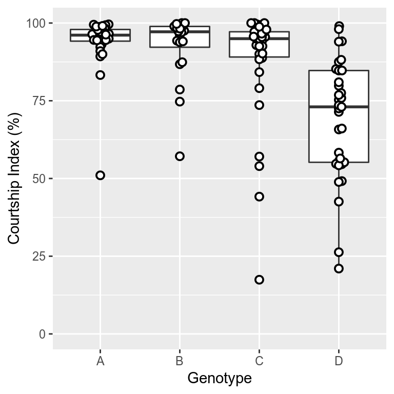

```r
indices <- courting_frames %>%
  filter(sex != "female") %>%
  group_by(uni_fly) %>%
  summarise(genotype = unique(genotype),
            CI = 100*sum(Courtship)/length(Frame),
            CIwF = 100*sum(CourtshipWithFacing)/length(Frame),
            approaching = 100*sum(Approaching)/length(Frame),
            contact = 100*sum(Contact)/length(Frame),
            circling = 100*sum(Encircling)/length(Frame),
            facing = 100*sum(Facing)/length(Frame),
            turning = 100*sum(Turning)/length(Frame),
            wing = 100*sum(WingGesture)/length(Frame)
            )

indices %>%
    ggplot(aes(x=genotype,y=CIwF)) +
    geom_boxplot(outlier.size = 0) +
    geom_beeswarm(shape = 21, colour = "black", fill = "white", size = 2, stroke = 1) +
    ylim(0,100) +
    ylab("Courtship Index (%)") +
    xlab("Genotype")
```

We can look at the individual courtship features to see what they look like. Approaching, facing, and maybe contact and wing extension look different. Will have to wait for the stats, though.

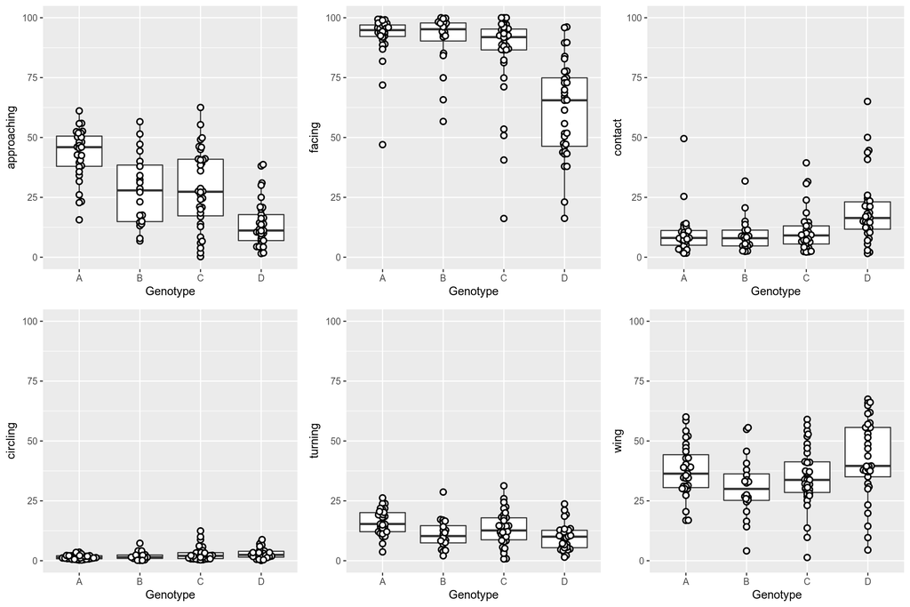

```r
p <- list()
courtship_features <- c("approaching","facing","contact","circling","turning","wing")
for (i in 1:length(courtship_features)) {
    p[[i]] <- indices %>%
        ggplot(aes_string(x="genotype",y=courtship_features[i])) +
        geom_boxplot(outlier.size = 0) +
        geom_beeswarm(shape = 21, colour = "black", fill = "white", size = 2, stroke = 1) +
        #geom_quasirandom(method = "smiley",shape = 21, colour = "black", fill = "white", size = 2, stroke = 1) +
        ylim(0,100) +
        ylab(as.name(courtship_features[i])) +
        xlab("Genotype")
}
plot_grid(plotlist = p,ncol = 3)
```

There doesn't look like much of an effect on courtship initiation, suggesting aDN>TNT start courting just fine.

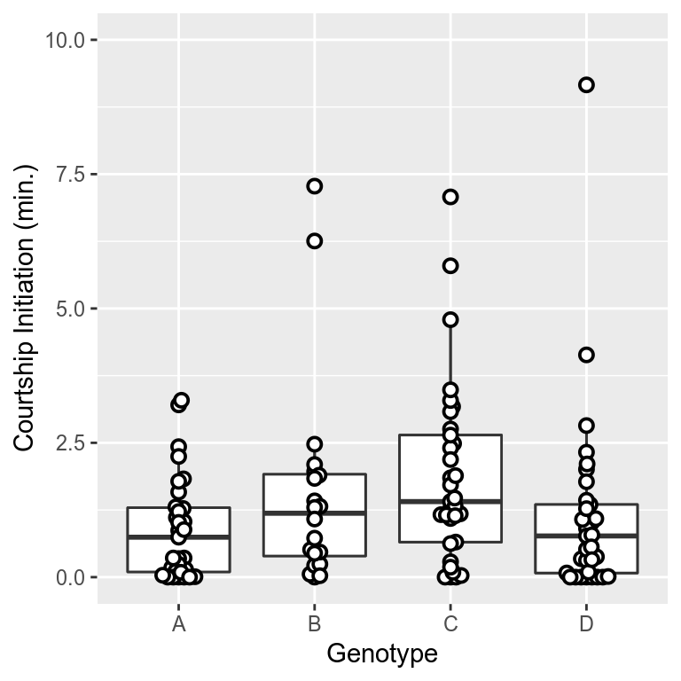

```r
ggplot(start_of_courtship_frames,aes(x=genotype,y=start_of_courtship/1500)) +
    geom_boxplot() +
    ylim(0,10) +
    geom_boxplot(outlier.size = 0) +
    geom_beeswarm(shape = 21, colour = "black", fill = "white", size = 2, stroke = 1) +
    ylab("Courtship Initiation (min.)") +
    xlab("Genotype")
```

There is an effect on cumulative copulation, with about half of the aDN>TNT not copulating within 1 hour.

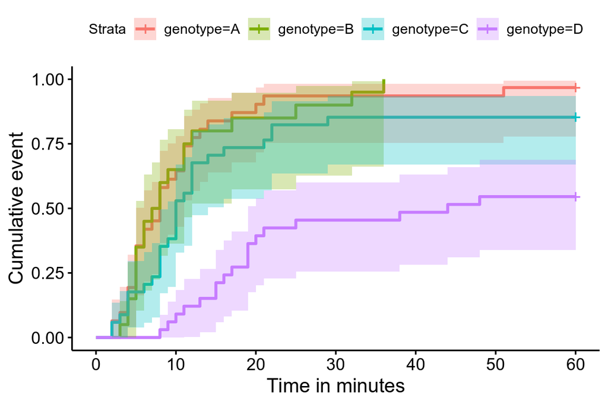

```r
df <- genotypes %>%
  mutate(status = if_else(is.na(copulation_time),0,1))
df$copulation_time <- replace_na(df$copulation_time,3600)
df$copulation_time <- round(as.numeric(df$copulation_time)/60)
fit <- survfit(Surv(copulation_time, status) ~ genotype, data = df)
ggsurv <- ggsurvplot(
            fit,
            data = df,
            risk.table = TRUE,
            pval = FALSE,
            conf.int = TRUE,
            xlim = c(0,60),
            xlab = "Time in minutes",
            break.time.by = 10,
            risk.table.y.text.col = T,
            risk.table.height = 0.25,
            risk.table.y.text = FALSE,
            ncensor.plot = TRUE,
            ncensor.plot.height = 0.25,
            fun = "event"
        )
ggsurv$plot
```

Looking at the position of the female while the male has it's wing extended, there is striking difference. The aDN>TNT males still generally keep the female close and in front, but there are more instances of the female being further away and behind. (*NB*: contralateral = left, ipsilateral = right, and the males postion is the centre).

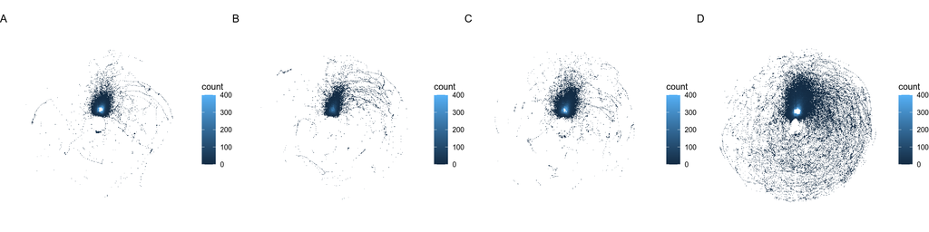

```r
p <- list()
male_genotypes <- c("A","B","C","D")
for (i in 1:length(male_genotypes)) {
    p[[i]] <- courting_frames %>%
                  filter(genotype==male_genotypes[i]) %>%
                  filter(max_wing_ang__rad > (35*pi/180)) %>%
                  ggplot(aes(x=ipsi_contra_rel_x,y=rel_y_other)) +
                  geom_bin2d(bins = c(400,400)) +
                  xlim(-20,20) +
                  ylim(-20,20) +
                  scale_fill_continuous(limits = c(0,400),na.value = "white") +
                  theme_void() +
                  coord_fixed() +
                  ggtitle(male_genotypes[i])
}
plot_grid(plotlist = p,ncol = 4)
```

There looks like there is an effect of both the distance between and facing angle. Here we write a little function to look at the probability density plots of a given feature with a mean trend line and 95% confidence intervals.

```r
mean_pd <- function(input,feature,low=0,high,wing=TRUE,wing_ang=NULL, n=512){
  input <- input %>%
    filter(sex != "female") %>%
    select(uni_fly,Frame,genotype,feature, max_wing_ang__rad)

  output <- tibble()
  flies <- unique(input$uni_fly)
  for (fly in flies) {
    temp0 <- input %>%
      filter(uni_fly == fly) %>%
      do(
        if(wing)
          filter(., max_wing_ang__rad > wing_ang)
        else
          .
      )
    #message(dim(temp0)[1])
    if(dim(temp0)[1]<100) next

    feat <- temp0[[feature]][!is.na(temp0[[feature]])]
    den <- density(feat, from = low, to = high, n = n, na.rm = TRUE)
    temp1 <- tibble()
    temp1 <- tibble(uni_fly = rep(unique(temp0$uni_fly),length(den[["x"]])),
                    genotype = rep(unique(temp0$genotype),length(den[["x"]])),
                    x = den[["x"]],
                    pd = den[["y"]])
    output <- bind_rows(output,temp1)
  }
  return(output)
}
```

And there is a striking difference in the density of facing angle. aDN>TNT males have a much shorter peak and higher tail.

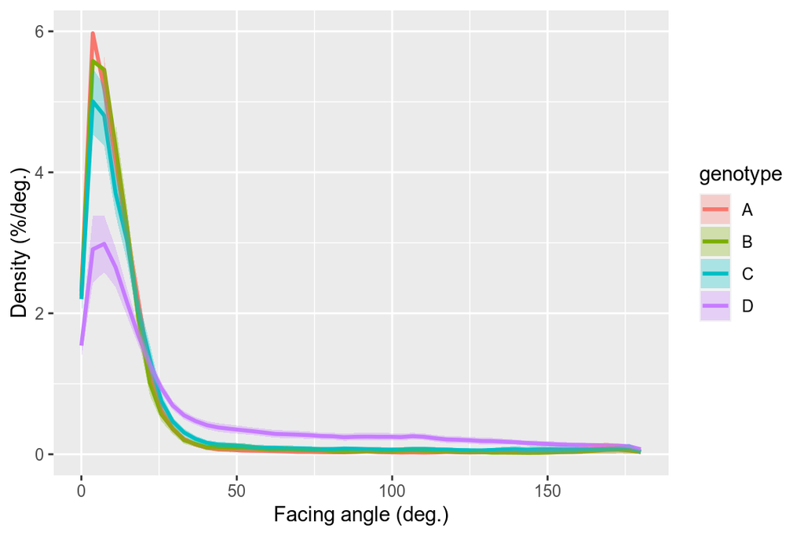

```r
facing_den <- mean_pd(input = courting_frames,feature = "facing_angle__rad",low = 0,high = pi, wing = FALSE, n=50)
facing_den %>%
  group_by(genotype,x) %>%
  summarise(y = mean(pd),
            err = qt(0.95,df=length(pd)-1)*sd(pd)/sqrt(length(pd))) %>%
  ggplot(aes(x=x*180/pi, y=100*y*pi/180)) +
  geom_line(aes(colour=genotype), size=1) +
  geom_ribbon(aes(ymin=if_else(y-err<0,0,(y-err)*100*pi/180), ymax=(y+err)*100*pi/180, fill=genotype), alpha = 0.3) +
  ylab("Density (%/deg.)") +
  xlab("Facing angle (deg.)") +
  ylim(0,6) +
  xlim(0,180)
```

And for distance, aDN>TNT males have a shorter peak and higher tail. But the peak is also shifted left.

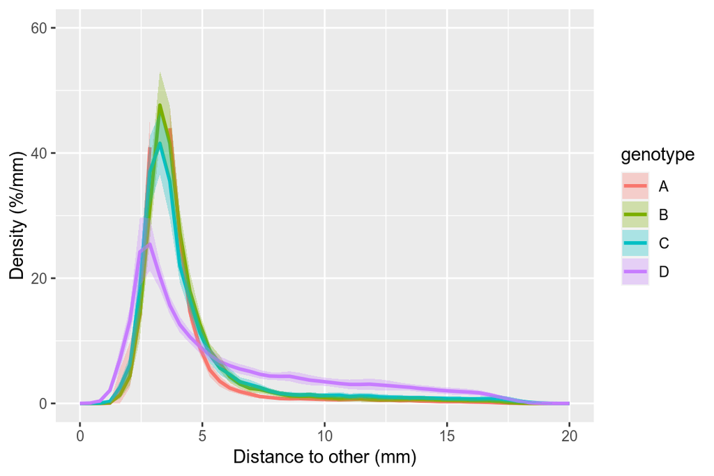

```r
distance_den <- mean_pd(input = courting_frames,feature = "dist_to_other__mm",low = 0,high = 20, wing = FALSE, n=50)
distance_den %>%
  group_by(genotype,x) %>%
  summarise(y = mean(pd),
            err = qt(0.95,df=length(pd)-1)*sd(pd)/sqrt(length(pd))) %>%
  ggplot(aes(x=x, y=y*100)) +
  geom_line(aes(colour=genotype), size=1) +
  geom_ribbon(aes(ymin=if_else(y-err<0,0,(y-err)*100), ymax=(y+err)*100, fill=genotype), alpha = 0.3) +
  ylab("Density (%/mm)") +
  xlab("Distance to other (mm)") +
  ylim(0,60) +
  xlim(0,20)
```

When we quantify the mean facing angle, mean distance to other, and minimum distance to other there are apparent differences between the flies. aDN>TNT males are on average facing "more away", are on average further away, but do frequently scooch up closer.

While watching the videos, it was noted that it looked like the aDN>TNT males extend both their wings simultaneously (but usually with one wing at a lesser angle than the other) more often than controls. Bilateral wing index is trending up in the experimental, but we'll have to wait for the stats to see what's what.

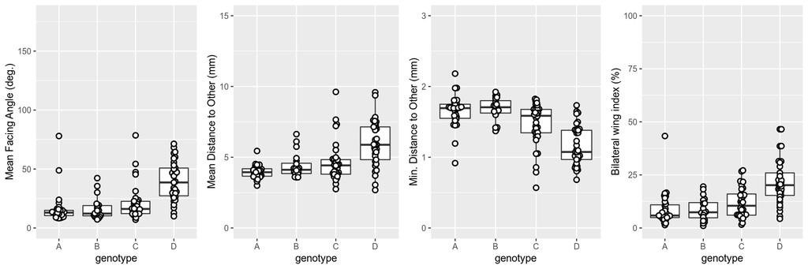

```r
p <- list()
p[[1]] <- courting_frames %>%
  filter(sex != "female") %>%
  group_by(uni_fly) %>%
  summarise(genotype = unique(genotype),
            facing = mean(facing_angle__rad)
  ) %>%
  ggplot(aes(x=genotype,y=facing*180/pi)) +
  geom_boxplot() +
  geom_beeswarm(shape = 21, colour = "black", fill = "white", size = 2, stroke = 1) +
  ylab("Mean Facing Angle (deg.)") +
  ylim(0,180)
p[[2]] <- courting_frames %>%
  filter(sex != "female") %>%
  group_by(uni_fly) %>%
  summarise(mean_dist = mean(dist_to_other__mm),
            genotype = unique(genotype)) %>%
  ggplot(aes(x=genotype, y=mean_dist)) +
  geom_boxplot() +
  geom_beeswarm(shape = 21, colour = "black", fill = "white", size = 2, stroke = 1) +
  ylab("Mean Distance to Other (mm)") +
  ylim(0,15)
p[[3]] <- courting_frames %>%
  filter(sex != "female") %>%
  group_by(uni_fly) %>%
  summarise(min_dist = min(dist_to_other__mm),
            genotype = unique(genotype)) %>%
  ggplot(aes(x=genotype, y=min_dist)) +
  geom_boxplot() +
  geom_beeswarm(shape = 21, colour = "black", fill = "white", size = 2, stroke = 1) +
  ylab("Min. Distance to Other (mm)") +
  ylim(0,3)
p[[4]] <- courting_frames %>%
  filter(sex != "female") %>%
  group_by(genotype) %>%
  group_by(uni_fly) %>%
  summarise(genotype = unique(genotype),
            both_wing_index = 100*sum(min_wing_ang__rad>(15*pi/180), na.rm = TRUE)/
              length(Frame)
  ) %>%
  ggplot(aes(x=genotype, y=both_wing_index)) +
  geom_boxplot() +
  geom_beeswarm(shape = 21, colour = "black", fill = "white", size = 2, stroke = 1) +
  ylab("Bilateral wing index (%)") +
  ylim(0,100)
plot_grid(plotlist = p,ncol = 4)
```

There isn't a strong difference in wing choice index ether. The aDN>TNT males trend a little lower, but they are clearly still preferring their ipsi-lateral wing.

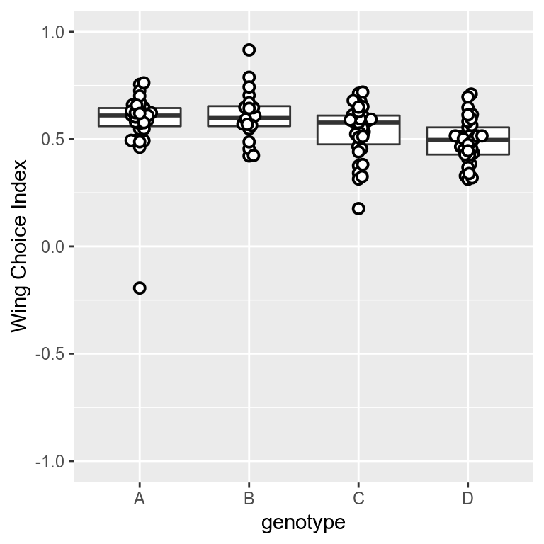

```r
courting_frames %>%
  filter(sex != "female") %>%
  group_by(uni_fly) %>%
  summarise(genotype = unique(genotype),
            wing_choice = (sum(abs(ipsi_wing_ang)>(35*pi/180),na.rm = T)-sum(abs(contra_wing_ang)>(35*pi/180),na.rm = T))/
              (sum(abs(ipsi_wing_ang)>(35*pi/180),na.rm = T)+sum(abs(contra_wing_ang)>(35*pi/180),na.rm = T))
  ) %>%
  ggplot(aes(x=genotype,y=wing_choice)) +
  geom_boxplot() +
  geom_beeswarm(shape = 21, colour = "black", fill = "white", size = 2, stroke = 1) +
  ylab("Wing Choice Index") +
  ylim(-1,1)
```

# **The Stats**

First lets compute a summary table of the features.

```r
court_summary <- courting_frames %>%
  filter(sex!="female") %>%
  group_by(uni_fly) %>%
  summarise(genotype = unique(genotype),
            initiation = min(Frame),
            CI = 100*sum(CourtshipWithFacing)/length(Frame),
            approaching = 100*sum(Approaching)/length(Frame),
            contact = 100*sum(Contact)/length(Frame),
            circling = 100*sum(Encircling)/length(Frame),
            facing = 100*sum(Facing)/length(Frame),
            turning = 100*sum(Turning)/length(Frame),
            wing = 100*sum(WingGesture)/length(Frame),
            time_behind = 100*sum(facing_angle__rad > (25*pi/180))/length(Frame),
            mean_facing_angle = mean(facing_angle__rad),
            mean_dist = mean(dist_to_other__mm),
            min_dist = min(dist_to_other__mm),
            bilateral_wing_index = 100*sum(min_wing_ang__rad>(15*pi/180), na.rm = TRUE)/length(Frame),
            uni_wing_index = 100*sum((max_wing_ang__rad>(35*pi/180) & min_wing_ang__rad < (15*pi/180)), na.rm = TRUE)/length(Frame),
            wing_choice = (sum(abs(ipsi_wing_ang)>(35*pi/180),na.rm = T)-sum(abs(contra_wing_ang)>(35*pi/180),na.rm = T))/
              (sum(abs(ipsi_wing_ang)>(35*pi/180),na.rm = T)+sum(abs(contra_wing_ang)>(35*pi/180),na.rm = T)),
            mean_min_wing = mean(min_wing_ang__rad)*180/pi
            )


temp <- courting_frames %>%
  filter(sex == "male")
uniq_fly <- unique(temp$uni_fly)
bi_wing_bouts <- tibble()
for (fly in uniq_fly) {
  temp2 <- temp %>%
    filter(uni_fly == fly) %>%
    mutate(bin_bilateral_wing = if_else(min_wing_ang__rad>(15*pi/180),1,0)
         )
  temp2$bin_bilateral_wing <- temp2$bin_bilateral_wing %>% replace_na(0)
  bilateral_wing_bouts <- rle(temp2[["bin_bilateral_wing"]])
  temp3 <- tibble(uni_fly = fly,
                  genotype = unique(temp2[["genotype"]]),
                  bilateral_wing_bout_rate = 60*25*sum(bilateral_wing_bouts$values==1)/length(temp2[["Frame"]]),
                  bilateral_wing_bout_length = mean(bilateral_wing_bouts$lengths[bilateral_wing_bouts$values==1])/25
                  )
  bi_wing_bouts <- bind_rows(bi_wing_bouts,temp3)
}
court_summary <- left_join(court_summary,bi_wing_bouts)
head(court_summary)
```

| uni_fly | genotype | initiation | CI | approaching | contact | circling | facing | turning | wing | time_behind | mean_facing_angle | mean_dist | min_dist | bilateral_wing_index | uni_wing_index | wing_choice | mean_min_wing | bilateral_wing_bout_rate | bilateral_wing_bout_length |
| --- | --- | --- | --- | --- | --- | --- | --- | --- | --- | --- | --- | --- | --- | --- | --- | --- | --- | --- | --- |
| Megan-2019_03_06_Courtship-DsxVglutTNT_Male_123_3_1 | C | 1906 | 99.43834 | 44.98168 | 9.279609 | 2.8571429 | 97.24054 | 25.934066 | 41.34310 | 4.566545 | 0.1765360 | 4.507624 | 1.824384 | 12.40537 | 26.61783 | 0.5836225 | 7.582485 | 29.67033 | 0.2508642 |
| Megan-2019_03_06_Courtship-DsxVglutTNT_Male_123_3_11 | C | 1 | 99.55631 | 62.53242 | 2.375427 | 0.7918089 | 98.27304 | 31.283276 | 54.27304 | 11.064846 | 0.2741270 | 4.686018 | 1.677388 | 21.42662 | 35.23549 | 0.5804196 | 9.410998 | 36.96246 | 0.3478116 |
| Megan-2019_03_06_Courtship-DsxVglutTNT_Male_123_3_13 | C | 16388 | 95.50139 | 27.49877 | 11.271062 | 3.9914935 | 92.03337 | 8.326517 | 35.48176 | 7.753967 | 0.2413049 | 3.912991 | 1.422346 | 18.79601 | 21.11893 | 0.6001805 | 8.766115 | 28.21855 | 0.3996522 |
| Megan-2019_03_06_Courtship-DsxVglutTNT_Male_123_3_15 | C | 1638 | 97.15285 | 16.89115 | 31.543882 | 8.7763025 | 92.62810 | 18.170925 | 59.02315 | 14.010449 | 0.3581104 | 3.109062 | 1.361217 | 20.28471 | 41.73896 | 0.3757581 | 10.422687 | 38.10574 | 0.3193962 |
| Megan-2019_03_06_Courtship-DsxVglutTNT_Male_123_3_17 | B | 1 | 86.75891 | 13.14046 | 20.628931 | 3.4213836 | 85.19078 | 8.570231 | 37.91195 | 15.807128 | 0.3370789 | 4.731492 | 1.696949 | 13.64361 | 24.53669 | 0.5858150 | 7.467442 | 18.23899 | 0.4488276 |
| Megan-2019_03_06_Courtship-DsxVglutTNT_Male_123_3_19 | B | 83 | 96.16919 | 51.44985 | 8.832136 | 2.5006651 | 94.02767 | 17.212024 | 40.67571 | 12.303804 | 0.2597527 | 4.215316 | 1.645010 | 19.49987 | 23.01144 | 0.5706974 | 8.864842 | 41.30088 | 0.2832850 |

And now we calculate a stats table and adjust for multiple comparisons/testing. Although not all the features were plotted above and calculating the stats for all the corresponding figures that we show for the in light experiments.

```r
features <- c("initiation","CI","mean_facing_angle","mean_dist","min_dist","bilateral_wing_index","bilateral_wing_bout_rate",
              "approaching","facing","contact","circling","turning","wing",
              "time_behind","uni_wing_index","bilateral_wing_bout_length","wing_choice")
figures <- c("4a","4b","4g","4h","4i","4j","4k",
             "s4a","s4b","s4c","s4d","s4e","s4f",
             "s4g","s4h","s4i","s4j")
all_pvals <- tibble()
anova_values <- tibble()
for (ii in 1:length(features)) {
  aov <- aov(court_summary[[features[ii]]]~court_summary[["genotype"]])
  temp_anova <- tibble(figure = figures[ii],
                       feature = features[ii],
                       df1 = summary(aov)[[1]][["Df"]][1],
                       df2 = summary(aov)[[1]][["Df"]][2],
                       fvalue = summary(aov)[[1]][["F value"]][1]
                    )
  anova_values <- bind_rows(anova_values,temp_anova)
  if (summary(aov)[[1]][["Pr(>F)"]][[1]]<0.05) {
    d_a <- t.test(court_summary[[features[ii]]][court_summary$genotype=="D"],court_summary[[features[ii]]][court_summary$genotype=="A"])
    d_b <- t.test(court_summary[[features[ii]]][court_summary$genotype=="D"],court_summary[[features[ii]]][court_summary$genotype=="B"])
    d_c <- t.test(court_summary[[features[ii]]][court_summary$genotype=="D"],court_summary[[features[ii]]][court_summary$genotype=="C"])
    temp_pvals <- tibble(figure = figures[ii],
                        feature = features[ii],
                        comparison = c("anova", "d-a t.test", "d-b t.test", "d-c t.test"),
                        pvals = c(summary(aov)[[1]][["Pr(>F)"]][[1]],d_a$p.value,d_b$p.value,d_c$p.value)
                    )
    all_pvals <- bind_rows(all_pvals,temp_pvals)
  } else {
      d_a <- NA
      d_b <- NA
      d_c <- NA
      temp_pvals <- tibble(figure = figures[ii],
                          feature = features[ii],
                          comparison = c("anova", "d-a t.test", "d-b t.test", "d-c t.test"),
                          pvals = c(summary(aov)[[1]][["Pr(>F)"]][[1]],NA,NA,NA)
                      )
      all_pvals <- bind_rows(all_pvals,temp_pvals)
  }
}

res0 <- survdiff(formula = Surv(copulation_time, status) ~ genotype, data = df)
res <- pairwise_survdiff(formula = Surv(copulation_time, status) ~ genotype, data = df, p.adjust.method = "none")
temp_pvals <- tibble(figure = "4c",
                     feature = "copulation",
                     comparison = c("chisq", "d-a log-rank test", "d-b log-rank test", "d-c log-rank test"),
                     pvals = c(1 - pchisq(res0$chisq, length(res0$n) - 1),res[["p.value"]][3,1],res[["p.value"]][3,2],res[["p.value"]][3,3])
                      )
all_pvals <- bind_rows(all_pvals,temp_pvals)

a_pd <- distance_den %>% filter(genotype == "A") %>% group_by(x) %>% summarise(y = mean(pd))
b_pd <- distance_den %>% filter(genotype == "B") %>% group_by(x) %>% summarise(y = mean(pd))
c_pd <- distance_den %>% filter(genotype == "C") %>% group_by(x) %>% summarise(y = mean(pd))
d_pd <- distance_den %>% filter(genotype == "D") %>% group_by(x) %>% summarise(y = mean(pd))
d_a <- ks.test(d_pd$y, a_pd$y, exact = TRUE)
d_b <- ks.test(d_pd$y, b_pd$y, exact = TRUE)
d_c <- ks.test(d_pd$y, c_pd$y, exact = TRUE)

temp_pvals <- tibble(figure = "4e",
                     feature = "dist_to_other",
                     comparison = c("d-a ks test", "d-b ks test", "d-c ks test"),
                     pvals = c(d_a$p.value,d_b$p.value,d_c$p.value)
                    )
all_pvals <- bind_rows(all_pvals,temp_pvals)

a_pd <- facing_den %>% filter(genotype == "A") %>% group_by(x) %>% summarise(y = mean(pd))
b_pd <- facing_den %>% filter(genotype == "B") %>% group_by(x) %>% summarise(y = mean(pd))
c_pd <- facing_den %>% filter(genotype == "C") %>% group_by(x) %>% summarise(y = mean(pd))
d_pd <- facing_den %>% filter(genotype == "D") %>% group_by(x) %>% summarise(y = mean(pd))
d_a <- ks.test(d_pd$y, a_pd$y, exact = TRUE)
d_b <- ks.test(d_pd$y, b_pd$y, exact = TRUE)
d_c <- ks.test(d_pd$y, c_pd$y, exact = TRUE)

temp_pvals <- tibble(figure = "4d",
                     feature = "facing_angle",
                     comparison = c("d-a ks test", "d-b ks test", "d-c ks test"),
                     pvals = c(d_a$p.value,d_b$p.value,d_c$p.value)
                    )
all_pvals <- bind_rows(all_pvals,temp_pvals)

all_pvals <- all_pvals %>%
  mutate(p_adj = p.adjust(pvals,"holm"),
         #sig = ifelse(p_adj<0.05,"y","n"),
         sig_level = ifelse(p_adj>0.1,"ns",
                            ifelse(p_adj>0.05,".",
                                    ifelse(p_adj>0.01,"*",
                                            ifelse(p_adj>0.001,"**",
                                                    ifelse(p_adj>0.001,"***","****")
                                                   )
                                           )
                                    )
                            )
         )
all_pvals <- all_pvals %>% arrange(figure)
all_pvals
```

| figure | feature | comparison | pvals | p_adj | sig_level |
| --- | --- | --- | --- | --- | --- |
| 4a | initiation | anova | 3.214393e-02 | 4.178711e-01 | ns |
| 4a | initiation | d-a t.test | 4.771777e-01 | 1.000000e+00 | ns |
| 4a | initiation | d-b t.test | 4.110434e-01 | 1.000000e+00 | ns |
| 4a | initiation | d-c t.test | 4.758856e-02 | 5.710627e-01 | ns |
| 4b | CI | anova | 4.269967e-09 | 2.561980e-07 | **** |
| 4b | CI | d-a t.test | 2.787243e-08 | 1.505111e-06 | **** |
| 4b | CI | d-b t.test | 8.458123e-07 | 3.975318e-05 | **** |
| 4b | CI | d-c t.test | 1.333316e-04 | 4.399943e-03 | ** |
| 4c | copulation | chisq | 2.184752e-08 | 1.201614e-06 | **** |
| 4c | copulation | d-a log-rank test | 5.547102e-09 | 3.272790e-07 | **** |

[output cut: 68 more lines]